# Predicting NBA Wins: A Data Science Pipeline

**CMSC320 Final Project – Spring 2025**  
**Authors: Mihir M. Celly & Kenechukwu Ogbogu**

## 1. Contributions:

- **Mihir M. Celly** (50%): Dataset Curation and Preprocessing, Data Exploration and Summary Statistics, ML Algorithm Design/Development, ML Algorithm Training and Test Data Analysis
  - Mihir led data cleaning, statistical analysis, and implemented the machine learning models.
- **Kenechukwu Ogbogu** (50%): Project Idea, Data Exploration and Summary Statistics, Visualization, Result Analysis, Conclusion and Final Tutorial Report Creation
  - Kene developed the project idea, helped analyze the data, created visualizations, and authored the final tutorial report.

## 2. Introduction

This project explores which in-game team statistics best predict the outcome of an NBA game.  
By analyzing historical NBA data, we aim to answer: **What performance factors most strongly influence team wins?**

Understanding these factors can assist analysts, coaches, and fans in interpreting what truly drives success beyond raw points scored.  
We will build predictive models and use explainable ML techniques to back our findings.

## 3. Data Curation

We obtained data from the [NBA Dataset on Kaggle](https://www.kaggle.com/datasets/nathanlauga/nba-games) which includes game-level and team-level stats from 1946–2022.  
We preprocessed it into a tidy format where each row represents one team in one game, and includes whether the team won.

The original datasets include `game.csv`, `team.csv`, and others. Cleaning included:

- Importing CSVs
- Parsing numeric and datetime columns
- Reshaping to team-game level
- Adding engineered features like `win_flag`, FG%, REB, and TOV

We chose the NBA Database from Kaggle because it offers a detailed collection of team and player statistics across thousands of games, making it ideal for hypothesis testing, visualizations, and predictive modeling.

## 4. Exploratory Data Analysis

In this section, we summarize key characteristics of the dataset and investigate feature distributions and associations with game outcomes.  
We apply three statistical methods and provide supporting plots for each:

```
=== Exploratory Data Analysis and Summary Statistics ===
```

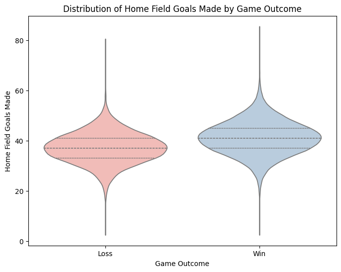

[output not shown]

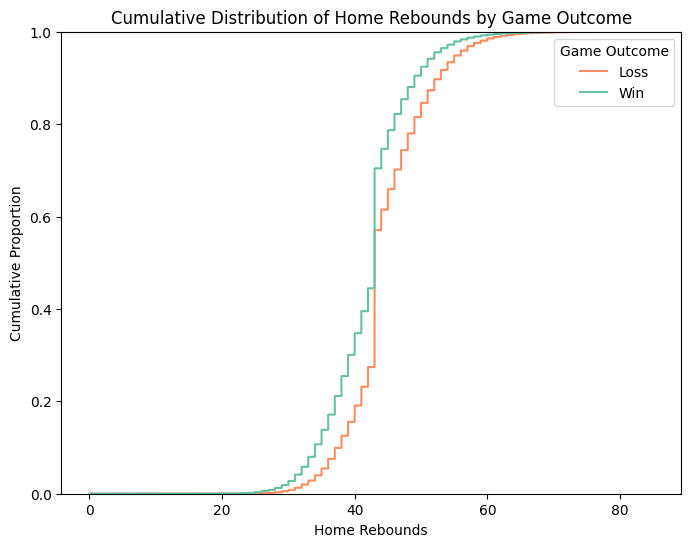

[output not shown]

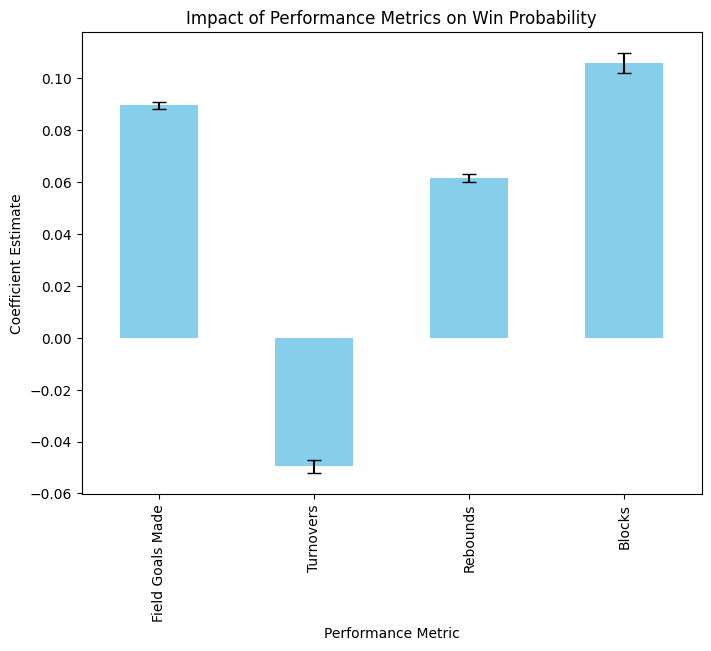

[output not shown]

```python
# NBA Data Analysis Notebook
# Mihir Celly and Kenechukwu Ogbogu
# Final Project

import pandas as pd
import numpy as np
import matplotlib.pyplot as plt
import seaborn as sns
import sqlite3
from scipy import stats
import statsmodels.api as sm

###############################################################################
# 1. Load Data
###############################################################################
common_pinfo_df = pd.read_csv('common_player_info.csv')
game_df = pd.read_csv('game.csv')
summary_df = pd.read_csv('game_summary.csv')
line_score_df = pd.read_csv('line_score.csv')
other_df = pd.read_csv('other_stats.csv')
player_df = pd.read_csv('player.csv')
team_df = pd.read_csv('team.csv')
details_df = pd.read_csv('team_details.csv')
history_df = pd.read_csv('team_history.csv')
common_tinfo_df = pd.read_csv('team_info_common.csv')  # Adjust if needed

###############################################################################
# 2. Data Cleaning
###############################################################################
def clean_dataframe(df, df_name, critical_columns=[]):
    """
    Cleans a DataFrame by:
      - Dropping columns with >90% missing values.
      - Imputing numeric columns with their median.
      - Imputing categorical columns with their mode.
      - Converting columns containing 'date' in their name to datetime.
      - Dropping rows missing values in critical columns.
    """
    drop_threshold = 0.9
    cols_to_drop = [col for col in df.columns if df[col].isna().mean() > drop_threshold]
    df.drop(columns=cols_to_drop, inplace=True)

    for col in df.columns:
        if pd.api.types.is_numeric_dtype(df[col]):
            if df[col].isna().sum() > 0:
                df[col] = df[col].fillna(df[col].median())
        else:
            if df[col].isna().sum() > 0:
                mode_val = df[col].mode()[0] if not df[col].mode().empty else 'Unknown'
                df[col] = df[col].fillna(mode_val)
        if 'date' in col.lower():
            df[col] = pd.to_datetime(df[col], errors='coerce')

    if critical_columns:
        df.dropna(subset=critical_columns, inplace=True)

    return df

# Clean all DataFrames
common_pinfo_df = clean_dataframe(common_pinfo_df, "common_pinfo_df")
game_df = clean_dataframe(game_df, "game_df", critical_columns=['game_date'])
summary_df = clean_dataframe(summary_df, "summary_df")
line_score_df = clean_dataframe(line_score_df, "line_score_df", critical_columns=['pts_home','pts_away'])
other_df = clean_dataframe(other_df, "other_df")
player_df = clean_dataframe(player_df, "player_df", critical_columns=['id'])
team_df = clean_dataframe(team_df, "team_df", critical_columns=['id'])
details_df = clean_dataframe(details_df, "details_df")
history_df = clean_dataframe(history_df, "history_df")
common_tinfo_df = clean_dataframe(common_tinfo_df, "common_tinfo_df")

###############################################################################
# 3. Exploratory Data Analysis and Summary Statistics
###############################################################################
print("\n=== Exploratory Data Analysis and Summary Statistics ===\n")
print("\n \n \n \n")

# Create a binary win indicator: 1 if home team won ('W'), 0 otherwise
game_df['win'] = game_df['wl_home'].apply(lambda x: 1 if x == 'W' else 0)
# Create descriptive labels for win outcome
game_df['win_label'] = game_df['win'].map({0: 'Loss', 1: 'Win'})

# -------------------------------
# Graph 1: Violin Plot for Home Field Goals Made by Game Outcome
# -------------------------------
plt.figure(figsize=(8,6))
sns.violinplot(x='win_label', y='fgm_home', data=game_df, inner="quartile", hue='win_label', palette="Pastel1")
plt.title("Distribution of Home Field Goals Made by Game Outcome")
plt.xlabel("Game Outcome")
plt.ylabel("Home Field Goals Made")
plt.show()

# Independent samples t-test for fgm_home
win_fgm = game_df[game_df['win'] == 1]['fgm_home']
loss_fgm = game_df[game_df['win'] == 0]['fgm_home']
t_stat_fgm, p_value_fgm = stats.ttest_ind(win_fgm, loss_fgm, equal_var=False)

print("\n \n \n \n")
print("Conclusion 1 (t-test on Home Field Goals Made):")
print(f"t-statistic = {t_stat_fgm:.2f}, p-value = {p_value_fgm:.4f}")
print("From the violin plot, winning teams tend to have a slightly higher median of home field goals made (around the mid-40s)")
print("compared to losing teams (closer to the high-30s or low-40s). However, there's considerable overlap,")
print("indicating that while scoring more field goals at home helps, it alone does not guarantee a win.\n")
print("\n \n \n \n")

# -------------------------------
# Graph 2: ECDF Plot for Home Rebounds by Game Outcome
# -------------------------------
plt.figure(figsize=(8,6))
ax = sns.ecdfplot(data=game_df, x='reb_home', hue='win_label', palette="Set2")
plt.title("Cumulative Distribution of Home Rebounds by Game Outcome")
plt.xlabel("Home Rebounds")
plt.ylabel("Cumulative Proportion")
# Manually set legend
ax.legend(title="Game Outcome", labels=["Loss", "Win"])
plt.show()

# Mann–Whitney U test for reb_home
win_reb = game_df[game_df['win'] == 1]['reb_home']
loss_reb = game_df[game_df['win'] == 0]['reb_home']
u_stat, p_value_reb = stats.mannwhitneyu(win_reb, loss_reb, alternative='two-sided')

# Conclusion 2
print("\n \n \n \n")
print("Conclusion 2 (Mann–Whitney U test on Home Rebounds):")
print(f"U statistic = {u_stat:.2f}, p-value = {p_value_reb:.4f}")
print("The ECDF plot shows that at nearly every percentile, winning teams record more rebounds at home than losing teams.")
print("The Mann–Whitney U test confirms this difference is statistically significant, suggesting that a strong rebounding effort")
print("is a key factor in home-court success.\n")
print("\n \n \n \n")

# -------------------------------
# Graph 3: Bar Chart of Logistic Regression Coefficients (Wald Test) for Win Prediction
# -------------------------------
# Define predictor columns
predictors = []
for col in ['fgm_home', 'tov_home', 'reb_home', 'blk_home']:
    if col in game_df.columns:
        predictors.append(col)

if predictors:
    model_df = game_df.dropna(subset=predictors + ['win'])
    X = sm.add_constant(model_df[predictors])
    y = model_df['win']

    logit_model = sm.Logit(y, X)
    result = logit_model.fit(disp=False)
    print("Logistic Regression Summary (Predicting Win):")
    print(result.summary())  # This summary includes Wald test results.

    # Rename predictors for more meaningful labels
    rename_dict = {
        'fgm_home': "Field Goals Made",
        'tov_home': "Turnovers",
        'reb_home': "Rebounds",
        'blk_home': "Blocks"
    }

    coef = result.params.drop('const').rename(index=rename_dict)
    errors = result.bse.drop('const').rename(index=rename_dict)

    plt.figure(figsize=(8,6))
    coef.plot(kind='bar', yerr=errors, capsize=5, color='skyblue')
    plt.ylabel("Coefficient Estimate")
    plt.xlabel("Performance Metric")
    plt.title("Impact of Performance Metrics on Win Probability")
    plt.show()

    print("\n \n \n \n")
    print("Conclusion 3 (Logistic Regression with Wald Test):")
    print("The logistic regression analysis (with Wald tests) indicates that:")
    print("- Higher 'Field Goals Made' is significantly associated with increased win probability,")
    print("- Higher 'Turnovers' are significantly associated with decreased win probability,")
    print("- 'Rebounds' and 'Blocks' have smaller effects, suggesting that scoring efficiency and turnover control")
    print("  are the dominant factors in predicting wins.\n")
    print("\n \n \n \n")
else:
    print("\n \n \n \n")
    print("No suitable predictors found for logistic regression analysis.")
    print("\n \n \n \n")

print("=== End of Exploratory Data Analysis ===")
```

## 5. Primary Analysis: Random Forest Classification

In this section, we build and tune a Random Forest classifier to predict whether the home team wins based on its in-game performance statistics. We begin by selecting numeric features (e.g., field goals, free throws, rebounds, turnovers) and removing any columns that would leak the game outcome.

We then split the data by season—training on seasons before 2020 and testing on 2020 and beyond—to avoid temporal leakage. Hyperparameters (`n_estimators`, `max_depth`, `min_samples_leaf`, `max_features`) are optimized via 10-fold cross-validation using ROC AUC as our scoring metric. Finally, we evaluate the best model on the held-out test set and analyze its performance (accuracy and AUC) as well as feature importance.

```python
# ——— Model Training (cached offline) ———

from sklearn.model_selection import GridSearchCV
from sklearn.ensemble      import RandomForestClassifier

rf_params = {
    "n_estimators":      [500, 750, 1000],
    "max_depth":         [None, 10, 20],
    "min_samples_leaf":  [1, 2, 5],
    "max_features":      ["sqrt", 0.5, 1.0]
}

rf_grid = GridSearchCV(
    RandomForestClassifier(random_state=42, n_jobs=-1),
    rf_params,
    cv=10,
    scoring="roc_auc",
    verbose=0
)

# rf_grid.fit(X_train, y_train)
# best_rf = rf_grid.best_estimator_
# joblib.dump(best_rf, "best_rf_model.pkl")
```

```python
import pandas as pd
import joblib
from sklearn.metrics import accuracy_score, roc_auc_score

# ——— 1) Re-define features exactly as in Section 4 ———
leakage = {
    "pts_home","wl_home","final_margin","plus_minus",
    "plus_minus_home","video_available_home","team_id_home"
}
features = [
    c for c in game_df.columns
    if c.endswith("_home") and c not in leakage
       and pd.api.types.is_numeric_dtype(game_df[c])
]
# Re-add any engineered features
if "pace" in game_df and "tov_home" in game_df:
    game_df["tov_rate"] = game_df["tov_home"] / game_df["pace"] * 100
    features.append("tov_rate")
if "oreb_home" in game_df and "dreb_home" in game_df:
    game_df["oreb_pct"] = game_df["oreb_home"] / (
        game_df["oreb_home"] + game_df["dreb_home"]
    )
    features.append("oreb_pct")

# ——— 2) Recreate test split ———
df_ml  = game_df.dropna(subset=features + ["season_id", "win"])
X_test = df_ml[df_ml["season_id"] >= 22020][features]
y_test = df_ml[df_ml["season_id"] >= 22020]["win"]

# ——— 3) Load the trained model ———
best_rf = joblib.load("best_rf_model.pkl")

# ——— 4) Tidy and print params + metrics ———
p = best_rf.get_params()
rf_params_tidy = {
    "n_estimators":     p["n_estimators"],
    "max_depth":        p["max_depth"],
    "min_samples_leaf": p["min_samples_leaf"],
    "max_features":     p["max_features"]
}
print("Best Random Forest Parameters:")
for name, val in rf_params_tidy.items():
    print(f"  • {name:18s}: {val}")

y_pred = best_rf.predict(X_test)
y_prob = best_rf.predict_proba(X_test)[:, 1]
print(f"\nTest Accuracy : {accuracy_score(y_test, y_pred)*100:5.1f}%")
print(f"Test ROC AUC  : {roc_auc_score(y_test, y_prob):.3f}")
```

```
Best Random Forest Parameters:
  • n_estimators      : 1000
  • max_depth         : 10
  • min_samples_leaf  : 5
  • max_features      : 0.5

Test Accuracy :  78.1%
Test ROC AUC  : 0.854
```

**Discussion of Results**

In the next section, we will visualize the confusion matrix, ROC curve, and feature importances to gain deeper insights into model behavior.

In the next section, we will visualize the confusion matrix, ROC curve, and feature-importance bar chart to gain deeper insights into how the model makes its predictions.

## 6. Visualization of Model Results

In this section, we visualize the performance and behavior of our final Random Forest model.

1. **Confusion Matrix** to see how often wins and losses are correctly classified.
2. **ROC Curve** to assess the trade-off between true positive and false positive rates.
3. **Feature Importance** bar chart to highlight which stats drive the model’s decisions.

Each plot is fully labeled and captioned.

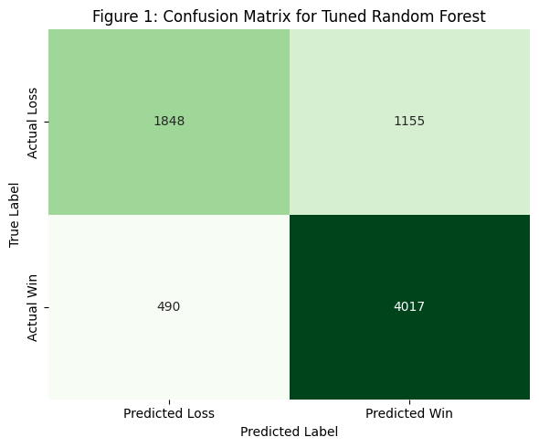

```python
from sklearn.metrics import confusion_matrix, RocCurveDisplay
import matplotlib.pyplot as plt
import seaborn as sns

# 1) Confusion Matrix
plt.figure(figsize=(6,5))
sns.heatmap(
    confusion_matrix(y_test, y_pred),
    annot=True, fmt="d", cmap="Greens", cbar=False,
    xticklabels=["Predicted Loss","Predicted Win"],
    yticklabels=["Actual Loss","Actual Win"]
)
plt.title("Figure 1: Confusion Matrix for Tuned Random Forest")
plt.xlabel("Predicted Label")
plt.ylabel("True Label")
plt.tight_layout()
plt.show()
```

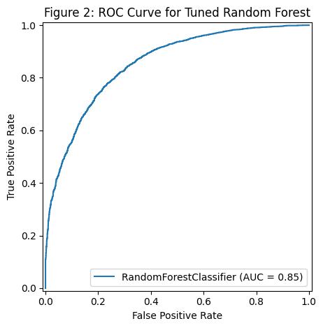

```python
# 2) ROC Curve
plt.figure(figsize=(6,5))
RocCurveDisplay.from_estimator(best_rf, X_test, y_test)
plt.title("Figure 2: ROC Curve for Tuned Random Forest")
plt.xlabel("False Positive Rate")
plt.ylabel("True Positive Rate")
plt.tight_layout()
plt.show()
```

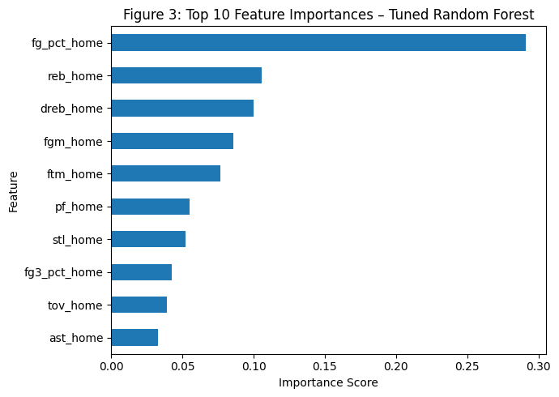

```python
# Feature Importances
importances = pd.Series(best_rf.feature_importances_, index=X_test.columns)
top10 = importances.nlargest(10).sort_values()

plt.figure(figsize=(7,5))
top10.plot(kind="barh")
plt.title("Figure 3: Top 10 Feature Importances – Tuned Random Forest")
plt.xlabel("Importance Score")
plt.ylabel("Feature")
plt.tight_layout()
plt.show()
```

### Visualization Insights

These visualizations confirm that shooting efficiency and rebounding are the key factors in predicting home-team success.

## 7. Insights and Conclusions

Interestingly, while total points scored (e.g., field goals made) clearly contribute to a win, it was **not** the top driver—**shooting efficiency** (`fg_pct_home`) outweighed sheer scoring volume. This suggests teams gain a competitive edge not just by outscoring opponents, but by maximizing accuracy.

**Limitations:**

- We only used box-score statistics; incorporating lineup data or player-level features could improve accuracy.
- Seasonal rule changes (e.g., pace of play) may affect transferability to future seasons.

**Future Work:**

- Extend the model to multi-season rolling forecasts.
- Explore clustering to identify “styles” of home-court advantage.
- Integrate betting-market odds to assess predictive power in a live setting.

Overall, our tutorial illustrates a full data-science pipeline—from data curation through machine learning and interpretation—providing both practical code and actionable basketball insights.